# Introduction to Time Series Analysis

Most of the statistics we have used so far -- the sample mean and its standard error in `Equity_Premium_Inference.ipynb`, the CAPM and multifactor regressions in `CAPM_BivariateRegression.ipynb` and `MultifactorModels_MultiVarRegression.ipynb` -- was developed under the convenient, but often unrealistic, assumption that observations are *independent* over time. This notebook introduces the basic tools for data where that assumption fails: time series whose values today are related to their values yesterday.

We have already seen one reason this matters. `Equity_Premium_Inference.ipynb` (and the Week 1 notes, `notes/week01_estimating_the_mean.md`) showed that positive autocorrelation makes naive standard errors too small, and used a simulated AR(1) process to show it. Here we step back and build the underlying concepts properly: autocorrelation, stationarity, white noise, testing for autocorrelation, autoregressive (AR) models, and forecasting with them.

*Acknowledgment*: This notebook was produced with the assistance of AI. I remain responsible for the content and any errors.

## Learning Objectives

By the end of this notebook, you should be able to:

1. Define a time series, the lag-$j$ autocovariance and autocorrelation, and the autocorrelation function (ACF).
2. Explain strict versus weak stationarity, and identify common sources of nonstationarity (trends, structural breaks, seasonality, stochastic trends).
3. Define white noise, and recognize that an uncorrelated series need not be independent.
4. Compute and interpret a sample ACF, including its confidence bands, in Python.
5. Explain the multiple-testing problem in reading an ACF plot, and explain and apply the Box-Pierce and Ljung-Box tests of zero autocorrelation.
6. Define the AR(1) model, explain its stationarity condition, derive its mean, and state its variance and autocorrelations, verifying them by simulation.
7. Explain why a random walk is nonstationary, and why this is the reason we analyze returns rather than prices.
8. Estimate AR(1) and AR(2) models with `statsmodels`, interpret the output, and compare models using information criteria.
9. Derive multi-step forecasts from an AR model as conditional expectations, and produce and interpret forecasts in Python.
10. (Optional, appendix) Work through the technical details behind the main text: the AR(1) variance and autocorrelation derivations, why the ACF confidence bands widen with the lag, the Ljung-Box weighting, the information criteria formulas, and how stationarity of an AR($p$) model relates to the "Roots" table in the `statsmodels` output.

## Instructions to Run

**Data:** This notebook uses four series from FRED (the Federal Reserve Bank of St. Louis's economic data service): real GDP (`GDPC1`), the consumer price index (`CPIAUCSL`), and Moody's seasoned BAA and AAA corporate bond yields (`BAA`, `AAA`), plus the NBER recession indicator (`USREC`) for shading recessions in the plots. A snapshot of these series, pulled from FRED on September 28, 2026 and covering January 1947 through June 2026, is already in this repo's `data/` folder as `data/fred_macro.csv`. FRED data are public domain, so small extracts like this can be redistributed freely. The notebook reads the snapshot rather than pulling live data because FRED regularly revises past values (GDP in particular), so a live pull would gradually drift away from the numbers discussed in the text. The first code cell includes commented-out lines that pull the latest data live from FRED instead, if you want to try it.

**If your data lives somewhere else:** Edit the `pd.read_csv("../data/fred_macro.csv", ...)` line in the first code cell (the path assumes this notebook lives in `notebooks/` and `data/` is a sibling folder).

**Package dependencies:** `numpy`, `pandas`, `matplotlib`, and `statsmodels` -- standard scientific-Python packages included in a typical Anaconda install. Otherwise: `pip install pandas numpy matplotlib statsmodels`. The optional live FRED pull also needs `pandas_datareader` (`pip install pandas_datareader`).

**Viewing the HTML export in Canvas:** If the equations below show up as raw text (things like `$\rho_j$`) instead of typeset math, don't use Canvas's built-in file preview -- download the file and open it directly in your browser instead. Canvas's preview sandboxes uploaded HTML and blocks the script that typesets the math; opening the downloaded file locally has no such restriction.

## Motivating Example: Three Macro-Financial Time Series

Start with some data. We will work with three key U.S. macro-financial quantities, observed quarterly from 1947Q2 through 2026Q2:

1. **Real GDP growth**: the quarter-over-quarter percentage change in real (inflation-adjusted) GDP, expressed as an annualized rate.
2. **Inflation**: the quarter-over-quarter percentage change in the CPI (quarterly average of the monthly index), expressed as an annualized rate.
3. **Default spread**: the difference between the BAA and AAA corporate bond yields (quarterly average of monthly values, in percentage points). BAA bonds are the lowest investment-grade rating; AAA the highest. The spread is a market price of corporate credit risk -- it tends to blow out in recessions and financial crises, when investors demand more compensation for bearing default risk.

Each of these matters to investors: inflation erodes real returns on bonds and cash, the default spread moves the prices of corporate bonds directly, and the state of the real economy drives corporate earnings. A natural question for each is: *if I know today's value, what does that tell me about next quarter's?* For independent data the answer would be "nothing." As the plots below show, that is not the world we live in.

Each series is a **time series** which is, informally, a time-ordered sequence of random variables. The code below loads the raw FRED data and constructs the three quarterly series. It also loads the NBER recession indicator (`USREC`), which we use to shade recessions in the plots.

```python
import datetime as dt
import numpy as np
import pandas as pd
import matplotlib.pyplot as plt
import statsmodels.api as sm
from statsmodels.tsa.ar_model import AutoReg

#Sample period. The end date is fixed so that the results match the text, even as FRED adds new data
start = dt.datetime(1947, 1, 1)
end = dt.datetime(2026, 6, 30)

#Load a snapshot of five FRED series (pulled 2026-09-28): real GDP (GDPC1, quarterly), CPI (CPIAUCSL, monthly),
#the BAA and AAA corporate bond yields (monthly), and the NBER recession indicator (USREC, monthly: 1 in months
#the NBER dates as recession, 0 otherwise). USREC is used only for plot shading
fred = pd.read_csv("../data/fred_macro.csv", index_col=0, parse_dates=True).loc[start:end]
raw = fred[['GDPC1', 'CPIAUCSL', 'BAA', 'AAA']].dropna(how='all')
usrec = fred['USREC']

#OPTIONAL: to pull the latest data live from FRED instead, uncomment the lines below (requires an internet
#connection and the pandas_datareader package). Results will then differ from the text, since FRED adds new
#observations and also revises old ones (GDP especially)
# import pandas_datareader.data as web
# end = dt.datetime.today()
# raw = pd.concat([web.DataReader(code, 'fred', start, end) for code in ['GDPC1', 'CPIAUCSL', 'BAA', 'AAA']],
#                 axis=1, sort=True)
# usrec = web.DataReader('USREC', 'fred', start, end)['USREC']

raw.tail()
```

| DATE | GDPC1 | CPIAUCSL | BAA | AAA |
| --- | --- | --- | --- | --- |
| 2026-02-01 | NaN | 327.460 | 5.81 | 5.30 |
| 2026-03-01 | NaN | 330.293 | 6.04 | 5.48 |
| 2026-04-01 | 24269.613 | 332.407 | 6.03 | 5.42 |
| 2026-05-01 | NaN | 333.979 | 6.10 | 5.56 |
| 2026-06-01 | NaN | 332.568 | 6.00 | 5.52 |

```python
#Convert to quarterly frequency: average the monthly values within each quarter (GDP is already quarterly)
q = raw.resample('QS').mean()

#Drop any trailing quarter in which the monthly series aren't yet available for all three months, so a
#partially observed current quarter isn't averaged over just one or two months.
#(Interior quarters are kept even with a missing month: e.g., October 2025 CPI was never published because of
#the federal government shutdown, so the 2025Q4 CPI average uses November and December only.)
monthly_cols = ['CPIAUCSL', 'BAA', 'AAA']
complete = raw[monthly_cols].resample('QS').count().min(axis=1) == 3
q = q.loc[:complete[complete].index[-1]]
q.index = q.index.to_period('Q')

#Sanity check: the quarterly index should have no gaps (the AR models below rely on consecutive quarters)
assert (q.index == pd.period_range(q.index[0], q.index[-1], freq='Q')).all()

#Annualized quarter-over-quarter growth rates, in percent: 100 x [(X_t / X_{t-1})^4 - 1]
df = pd.DataFrame({
    'GDP': 100 * ((q['GDPC1'] / q['GDPC1'].shift(1))**4 - 1),
    'INF': 100 * ((q['CPIAUCSL'] / q['CPIAUCSL'].shift(1))**4 - 1),
    'DEFSPR': q['BAA'] - q['AAA'],
})

#Drop quarters where any series is missing (the first quarter, which has no growth rate, and any recent
#quarter where GDP hasn't been released yet), so all three series share one sample
df = df.dropna()
print(f"Sample: {df.index[0]} to {df.index[-1]}, T = {len(df)} quarters")
df.describe().round(2)
```

```
Sample: 1947Q2 to 2026Q2, T = 317 quarters
```

|  | GDP | INF | DEFSPR |
| --- | --- | --- | --- |
| count | 317.00 | 317.00 | 317.00 |
| mean | 3.19 | 3.56 | 0.94 |
| std | 4.50 | 3.30 | 0.41 |
| min | -27.98 | -8.85 | 0.35 |
| 25% | 1.24 | 1.64 | 0.67 |
| 50% | 3.12 | 3.09 | 0.83 |
| 75% | 4.95 | 4.62 | 1.11 |
| max | 34.86 | 17.27 | 3.02 |

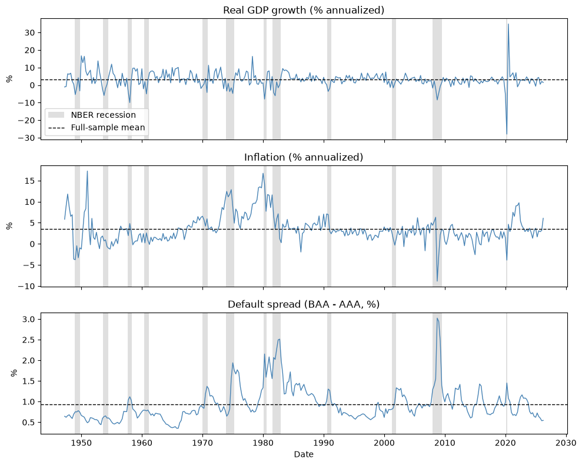

```python
#Find the start and end of each NBER recession: runs of consecutive months with USREC = 1
rec = usrec.loc[df.index[0].start_time:]
run_id = (rec != rec.shift()).cumsum()
recessions = [(g.index[0], g.index[-1] + pd.offsets.MonthEnd(1)) for _, g in rec[rec == 1].groupby(run_id[rec == 1])]

def shade_recessions(ax):
    for i, (rec_start, rec_end) in enumerate(recessions):
        ax.axvspan(rec_start, rec_end, color="gray", alpha=0.25, linewidth=0,
                   label="NBER recession" if i == 0 else None)

#Plot each series in its own panel, with its full-sample mean as a dashed reference line and recessions shaded
dates = df.index.to_timestamp()
panels = [("GDP", "Real GDP growth (% annualized)"),
          ("INF", "Inflation (% annualized)"),
          ("DEFSPR", "Default spread (BAA - AAA, %)")]

fig, axes = plt.subplots(3, 1, figsize=(10, 8), sharex=True)
for ax, (col, label) in zip(axes, panels):
    shade_recessions(ax)
    ax.plot(dates, df[col], color="steelblue", linewidth=1)
    ax.axhline(df[col].mean(), color="black", linestyle="--", linewidth=1, label="Full-sample mean")
    ax.set_title(label)
    ax.set_ylabel("%")
axes[0].legend(loc="lower left")
axes[-1].set_xlabel("Date")
fig.tight_layout()
plt.show()
```

### Comments on the plot

None of the three series looks like independent draws from a fixed distribution ("i.i.d." data). Several features stand out:

1. **Persistence.** Inflation and especially the default spread wander slowly around their long-run averages, staying above (or below) the mean for years at a time. If you know this quarter's default spread, you have a very good idea of next quarter's. Real GDP growth is much noisier, and its persistence is harder to see by eye -- we will measure it formally below.
2. **Apparently time-varying means.** Inflation was high and variable in the 1970s and early 1980s, then fell sharply and stayed low after the Federal Reserve's disinflation under Paul Volcker, before surging again in 2021-22.
3. **Time-varying volatility.** GDP growth fluctuations became visibly smaller after the mid-1980s (a period economists call the "Great Moderation"), until the COVID-19 shock of 2020.
4. **Links to the business cycle.** The shaded bands mark recessions as dated by the National Bureau of Economic Research (NBER). GDP growth falls, usually below zero, in nearly every recession, and the default spread rises during or just after nearly every recession, as investors demand more compensation for bearing credit risk when defaults become more likely. Because recessions last several quarters, they are themselves one source of persistence.
5. **Extreme observations.** The 2020 COVID collapse and rebound in GDP growth are far outside anything else in the sample. As we will see, a couple of observations like this can noticeably affect the statistics we compute.

One of our main goals is to build statistical models -- *time series models* -- capable of generating the kind of persistence we see in these (and many other) macro-financial series, and to use them for forecasting.

## Time Series and Autocorrelation

A **stochastic process** is a sequence of random variables, denoted $\left\{ y_{i} \right\} = y_{1}, y_{2},\ldots$

A **time series** is a stochastic process indexed by time, $\left\{ y_{t} \right\} = y_{1}, y_{2},\ldots$ The data we observe -- e.g., the roughly 300 quarterly default spreads plotted above -- are one *realization* of the process.

Examples:

1. *i.i.d. random variables*: $y_{t} \sim N(0,\sigma^2)$, independently over time.
2. *Random walk*: $y_{t} = y_{t-1} + \epsilon_{t}$, with $\epsilon_{t} \sim N(0,\sigma^2)$ independent over time.

Many real-world datasets in finance can be viewed as outcomes of a time series process, including:

1. Stock and bond prices and returns
2. Trading volume
3. Inflation rates and interest rates
4. Quarterly accounting performance measures

To make progress analyzing time series, we need some notion of regularity -- some sense in which the process behaves "the same way" over time, so that the past is informative about the future. The usual notion in econometrics is *stationarity*. Before defining it, we need **autocovariances**.

### Autocovariance and autocorrelation

*Intuition*: You are familiar with the covariance $\text{Cov}(X,Y)$ between two random variables $X$ and $Y$. A nonzero covariance captures a (linear) relationship between the two variables.

In a time series, each date's outcome is a (different) random variable: $y_{1}$ and $y_{2}$ are two different random variables, the values of $y$ at time 1 and time 2. With that understanding, an **autocovariance** ("auto" = self) is just the covariance between the *same* series at two different dates. For example, $\text{Cov}(y_{1},y_{2})$ is an autocovariance.

The two dates don't have to be adjacent. The **lag-$j$ autocovariance** of $y_{t}$ is defined as

$$\gamma_{j,t} = \text{Cov}(y_{t},y_{t-j})$$

In words: how much this period's value co-moves with the value $j$ periods earlier. Note that the lag-0 autocovariance is just the variance: $\gamma_{0,t} = \text{Cov}(y_t, y_t) = \text{Var}(y_t)$.

The **lag-$j$ autocorrelation** rescales the autocovariance to lie between $-1$ and $1$, exactly as a correlation rescales a covariance:

$$\rho_{j,t} = \text{Corr}(y_{t},y_{t-j}) = \frac{\gamma_{j,t}}{\sigma(y_{t})\, \sigma(y_{t-j})}$$

A lag-1 autocorrelation of 0.9 for the default spread, for instance, would mean that quarters with an unusually high spread are very likely to be followed by another quarter with a high spread.

The **autocorrelation function (ACF)** is the autocorrelation viewed as a function of the lag $j$ -- often plotted, as we will do below.

## Stationarity

A **stationary** time series is one whose distributional properties are stable over time. There are two common versions:

1. *Strict stationarity*: the joint distribution of $(y_{t}, y_{t+1}, \ldots, y_{t+k})$ is the same for every starting date $t$ (and every $k$).
2. *Weak stationarity*: the mean and autocovariances exist and do not depend on time:

$$E[y_{t}] = \mu, \qquad \text{Cov}(y_{t},y_{t-j}) = \gamma_{j} \quad \text{for all } t$$

Strict stationarity implies weak stationarity provided the variance is finite, but not vice versa. Weak stationarity is the more common assumption in practice, and it will be our focus.

The key requirement is that the mean and the autocovariances *do not depend on the date $t$*: the autocovariance depends only on the lag $j$ between the two observations. That is why, for a stationary series, we can drop the $t$ subscript and write $\gamma_{j}$ and $\rho_{j}$ (or $\gamma(j)$, $\rho(j)$). It is also what makes estimation possible: if $\text{Cov}(y_t, y_{t-1})$ is the same for every $t$, then every adjacent pair of observations in our sample is informative about the same single number $\gamma_1$.

One consequence: for a stationary time series, $\rho_{j} = \rho_{-j}$, so the correlation with the value $j$ periods *ahead* is the same as with the value $j$ periods *back*. (See the appendix for why.)

A number of features can make a time series *nonstationary*, i.e., violate the conditions above:

1. *Trends*: the mean of the series increases (or decreases) over time. E.g., population levels, or the level of GDP.
2. Permanent *structural break* in the level of a series: the mean changes permanently at some date.
3. Permanent structural break in the volatility (or autocovariances) of a series. The GDP growth data above suggest a downward break in volatility in the mid-1980s.
4. *Seasonality*: e.g., gasoline prices tend to be higher in summer, driven by seasonal driving demand, so the mean depends on the time of year.
5. *Stochastic trend*: the series is subject to *permanent* random shocks, so it never reverts to a fixed mean. These are called "integrated" or "unit root" processes; the random walk is the leading example (more below).

Many nonstationary series can be *transformed* into a stationary series. Examples:

1. De-trend a series with a deterministic trend (e.g., subtract a fitted time trend).
2. Remove seasonal effects (the "seasonally adjusted" macroeconomic series produced by the BLS, BEA, and other government agencies -- including the CPI and GDP series we use here).
3. Take growth rates or differences -- which is exactly what we did to the GDP and CPI *levels* above, which are clearly trending.

The remaining stationary component is often called the **cycle** component.

### White noise

A time series is **white noise** if it is (weakly) stationary with mean zero and $\rho_{j} = 0$ for all $j \neq 0$. (Some authors allow a nonzero mean; the key feature is the absence of autocorrelation.)

In words, white noise is an *uncorrelated*, stationary time series. By themselves, white noise processes are rather "boring" -- past values say nothing (linearly) about future values -- but they are the crucial building block for more interesting time series, as we will see with AR models below.

Two common refinements of the definition:

1. *Independent white noise*: white noise where $y_{t}$ and $y_{t-j}$ are independent for all $j \neq 0$.
2. *Independent Gaussian white noise*: independent white noise such that $y_{t}$ is also Normally distributed for all $t$.

Each refinement strengthens the previous definition: a series can be uncorrelated without being independent. Daily stock returns are the classic example -- nearly uncorrelated from day to day, but with clustered volatility (see the appendix).

## Sample Autocovariances and Autocorrelations

*Intuition*: Set autocorrelations aside for a second and recall the mean and variance of a random variable. These are *population* parameters, and in most applied settings they are *unknown* -- we use data to *estimate* them:

- The standard estimate of the population mean is the sample mean.
- The standard estimate of the population variance is the sample variance (sometimes with a "degrees of freedom" correction).

Autocovariances and autocorrelations are *also* population parameters that we generally do not know. So a standard statistical problem is to *estimate* them and conduct statistical inference about them.

Let $\bar{y}$ be the sample mean and $\tilde{y}_{t} = y_{t} - \bar{y}$ the de-meaned values of $y_{t}$, for a sample $t = 1, \ldots, T$.

The **lag-$j$ sample autocovariance** is

$$\hat{\gamma}_{j} = \frac{1}{T}\sum_{t=j+1}^{T} \tilde{y}_{t}\,\tilde{y}_{t-j}$$

This is the sample analog of $\text{Cov}(y_t, y_{t-j})$: average the product of each de-meaned observation with the de-meaned observation $j$ periods earlier. (Only $T - j$ such pairs exist, but the conventional estimator still divides by $T$.)

The **lag-$j$ sample autocorrelation** is

$$\hat{\rho}_{j} = \frac{\hat{\gamma}_{j}}{\hat{\gamma}_{0}}$$

i.e., the sample autocovariance divided by the sample variance. (Under stationarity, $\sigma(y_t)\sigma(y_{t-j}) = \gamma_0$, so this mirrors the population definition.)

The *sample ACF* is $\hat{\rho}_{j}$ as a function of $j$. Plotting it gives a quick visual sense of the degree of autocorrelation, and is standard practice when working with time series.

Below, I produce sample ACFs using the `statsmodels` package for:

1. Simulated data from an i.i.d. Normal distribution (so the *true* autocorrelations are all zero), and
2. The GDP growth, inflation, and default spread series.

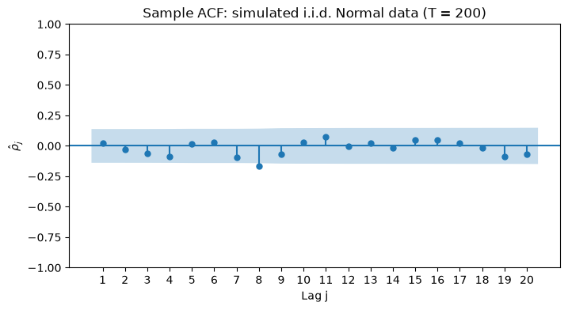

```python
#Simulated Gaussian white noise (plus a constant mean), with a fixed seed so results are reproducible
rng = np.random.RandomState(10)
T_sim = 200
xmean = 10
xstd = 4
xsim = rng.normal(loc=xmean, scale=xstd, size=T_sim)

#Sample ACF plot. zero=False drops the lag-0 autocorrelation, which is always exactly 1 and so uninformative
fig, ax = plt.subplots(figsize=(8, 4))
sm.graphics.tsa.plot_acf(xsim, lags=20, zero=False, ax=ax,
                         title=f"Sample ACF: simulated i.i.d. Normal data (T = {T_sim})")
ax.set_xticks(range(1, 21))
ax.set_xlabel("Lag j")
ax.set_ylabel(r"$\hat\rho_j$")
plt.show()
```

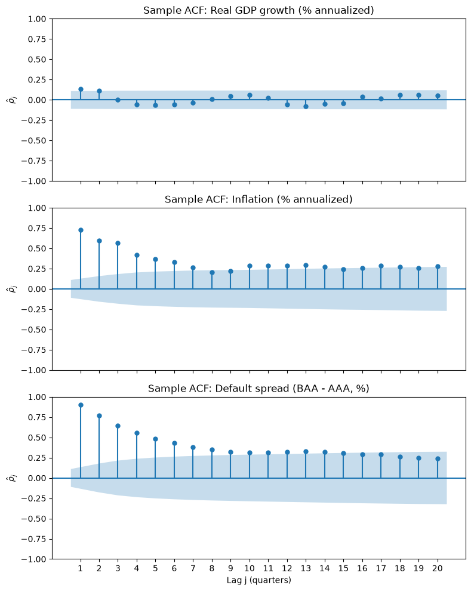

```python
#Sample ACFs for the three macro-financial series
fig, axes = plt.subplots(3, 1, figsize=(8, 10), sharex=True)
for ax, (col, label) in zip(axes, panels):
    sm.graphics.tsa.plot_acf(df[col], lags=20, zero=False, ax=ax, title=f"Sample ACF: {label}")
    ax.set_ylabel(r"$\hat\rho_j$")
axes[-1].set_xticks(range(1, 21))  #shared x-axis, so this applies to all three panels
axes[-1].set_xlabel("Lag j (quarters)")
fig.tight_layout()
plt.show()
```

### Discussion of results

Key points:

1. For the simulated i.i.d. Normal data, the sample autocorrelations are small in magnitude, scattered on both sides of zero. That is good, because *in truth all of the autocorrelations are zero* for this series -- the nonzero estimates are pure sampling noise. (One of them, at lag 8, does poke just outside the shaded band. Keep that in mind; we come back to it below.)
2. The default spread and inflation show large, positive autocorrelations that decay only slowly as the lag grows. This is *positive serial correlation* (persistence), and it confirms what we saw by eye in the time-series plots. The default spread is the most persistent, with a lag-1 autocorrelation around 0.9.
3. Real GDP growth is a different story: its autocorrelations are positive but small (on the order of 0.1 at lags 1 and 2) and essentially zero thereafter. As we will see below, this is partly an artifact of the 2020 COVID observations -- a huge drop followed by a huge rebound looks like strong *negative* autocorrelation, which drags the estimates toward zero.

**What is the shaded area?** It represents a 95% band for testing whether each individual autocorrelation is zero. It is built from the following large-sample result. Suppose $\left\{ y_{t} \right\}$ is independent white noise (i.i.d. with finite variance; Normality is not needed). Then for each $j \geq 1$,

$$\sqrt{T}\, \hat{\rho}_{j} \xrightarrow{d} N(0,1)$$

This implies that, under the null of no autocorrelation, the sample autocorrelation has an approximate standard error of $1/\sqrt{T}$. For example, with our $T = 200$ simulated observations, the standard error is $1/\sqrt{200} \approx 0.07$, and a 95% band around zero is $\pm 1.96 \times 0.07 \approx \pm 0.14$.

The most common hypothesis test here is of the null $\rho_{j} = 0$. Sample autocorrelations that fall *outside* the shaded region are those for which we reject that null at the 5% significance level.

You may notice the shaded region gets wider at higher lags, dramatically so for the default spread. That is because `statsmodels` adjusts the band for any autocorrelation at shorter lags; see the appendix.

### Joint tests for zero autocorrelation

Look again at the ACF of the simulated i.i.d. series: the lag-8 sample autocorrelation falls outside the shaded band, so we would *reject* the null $\rho_8 = 0$. That is an incorrect conclusion, because the null is true for this series. (Re-run it with different random seeds and you will see such false rejections, at various lags, quite often.) The issue is **multiple testing**. Each individual test has a 5% significance level, so we tolerate a false rejection 5% of the time -- but the ACF plot shows 20 such tests at once! If the tests were independent, the probability of at least one false rejection among 20 would be

$$1 - 0.95^{20} \approx 0.64,$$

i.e., about two times in three. The probability of rejecting the null for *at least one* lag grows rapidly with the number of lags we look at.

For this reason, we often want to *jointly* test whether $\rho_{j} = 0$ for *all* $j \neq 0$. We can't literally test infinitely many autocorrelations, so instead we choose an upper bound $K$ and test $\rho_{1} = \rho_{2} = \cdots = \rho_{K} = 0$.

The **Box-Pierce $Q$ statistic** is

$$Q(K) = T\sum_{k=1}^{K} \hat{\rho}^2_{k}$$

*Intuition*: each $\sqrt{T}\hat\rho_k$ is approximately $N(0,1)$ under the null, so $T\hat\rho_k^2$ is approximately a squared standard Normal, and $Q(K)$ adds up $K$ of these. Large squared autocorrelations at *any* lag push $Q$ up. Under the null hypothesis, $Q(K) \xrightarrow{d} \chi^2(K)$, a chi-squared distribution with $K$ degrees of freedom.

In practice, software usually reports a slightly fancier version of this statistic, the **Ljung-Box test**. It reweights the terms in the sum a little to give better finite-sample behavior, but it has the same $\chi^2(K)$ distribution under the null and works exactly the same way. With samples of a few hundred observations, the two statistics are very close. The code below uses the Ljung-Box version (see the appendix for its formula).

Let's first check the multiple-testing claim, and the Ljung-Box test's behavior, by simulation: generate many white-noise samples of size $T = 200$, and for each record (a) whether *any* of the 20 individual lag tests rejects, and (b) whether the Ljung-Box test with $K = 10$ rejects at the 5% level.

```python
n_reps = 1000
K = 10
band = 1.96 / np.sqrt(T_sim)  #simple 95% band for each individual autocorrelation

rng = np.random.RandomState(20)
any_individual_reject = np.zeros(n_reps, dtype=bool)
lb_reject = np.zeros(n_reps, dtype=bool)
for r in range(n_reps):
    x = rng.normal(size=T_sim)
    rho_hat = sm.tsa.acf(x, nlags=20)[1:]  #drop lag 0
    any_individual_reject[r] = np.any(np.abs(rho_hat) > band)
    lb_reject[r] = sm.stats.acorr_ljungbox(x, lags=[K])['lb_pvalue'].iloc[0] < 0.05

print(f"Share of white-noise samples where at least one of 20 lag tests rejects: {any_individual_reject.mean():.2f}")
print(f"Share of white-noise samples where the Ljung-Box test (K={K}) rejects:     {lb_reject.mean():.2f}")
```

```
Share of white-noise samples where at least one of 20 lag tests rejects: 0.57
Share of white-noise samples where the Ljung-Box test (K=10) rejects:     0.06
```

Looking at 20 individual lags, we "find" autocorrelation in more than half of the pure white-noise samples -- close to the rough $1 - 0.95^{20}$ calculation. The Ljung-Box test, by contrast, rejects in roughly 5% of samples, which is exactly what a correctly sized 5% test should do.

Now let's apply the Ljung-Box test to our simulated series and to the three real series, for both $K = 2$ and $K = 10$. The `acorr_ljungbox` function in `statsmodels` returns the statistic and p-value for each $K$ requested.

```python
series = {'Simulated i.i.d.': pd.Series(xsim), 'GDP growth': df['GDP'],
          'Inflation': df['INF'], 'Default spread': df['DEFSPR']}

lb_rows = {}
for name, s in series.items():
    lb = sm.stats.acorr_ljungbox(s, lags=[2, K])
    lb_rows[name] = {f'LB({k}) stat': lb.loc[k, 'lb_stat'] for k in lb.index} | \
                    {f'LB({k}) p-value': lb.loc[k, 'lb_pvalue'] for k in lb.index}
lb_table = pd.DataFrame(lb_rows).T
lb_table.round(4)
```

|  | LB(2) stat | LB(10) stat | LB(2) p-value | LB(10) p-value |
| --- | --- | --- | --- | --- |
| Simulated i.i.d. | 0.2777 | 11.7181 | 0.8704 | 0.3044 |
| GDP growth | 10.0576 | 15.7908 | 0.0065 | 0.1058 |
| Inflation | 281.9955 | 601.5544 | 0.0000 | 0.0000 |
| Default spread | 447.3388 | 970.5867 | 0.0000 | 0.0000 |

### Discussion of Ljung-Box results

For the simulated white noise, the Ljung-Box statistics are modest and the p-values are large: *little evidence against the null of zero autocorrelation*, as it should be, since in truth this series is white noise.

For inflation and the default spread, the statistics are enormous and the p-values are essentially zero, whichever $K$ we use.

GDP growth is the interesting case. With $K = 2$ the test rejects at the 5% level, but with $K = 10$ it does *not*. GDP growth's autocorrelation is concentrated in the first two lags, so adding eight more lags with near-zero autocorrelations mostly adds noise and dilutes the test. The choice of $K$ matters, and it should be made *before* looking at the results rather than by shopping for the one that rejects.

**Bottom line:** There is overwhelming evidence against the hypothesis that inflation or the default spread is white noise, and more modest (but real) evidence against it for GDP growth. That raises the next question: if these series are autocorrelated, how should we *model* that autocorrelation?

## Autoregressive Models

So far we have asked whether a series is stationary, and for stationary series we have estimated and tested autocorrelations. Many series exhibit *persistence*, i.e., clear evidence of nonzero autocorrelation (also called *serial correlation*) -- including all three of our real-world series.

If a series is stationary and persistent, *how can we model its dynamic or cyclical behavior?* The best-known class of time series models is the class of **autoregressive moving average (ARMA) models**. Here I focus on the most popular sub-class, **autoregressive (AR)** models.

The simplest example is the **AR(1)** model for a stationary time series $y_{t}$:

$$y_{t} = c + \phi\, y_{t-1} + \epsilon_{t},$$

where $\epsilon_{t}$ is *mean-zero white noise* (the "shock" or "innovation") with variance $\sigma^2_\epsilon$, and $\epsilon_t$ is uncorrelated with all past values $y_{t-1}, y_{t-2}, \ldots$

The model looks like a regression, except that instead of some generic $x_{t}$ on the right-hand side, the regressor is the *lagged* value of $y$ itself -- hence "auto" regression. The "(1)" means one lag of $y$ appears.

### How past shocks feed through: the $\phi = 0.5$ example

To get a feel for the model, temporarily set $c = 0$ and $\phi = 0.5$:

$$y_{t} = 0.5\, y_{t-1} + \epsilon_{t}$$

The same equation holds one period earlier: $y_{t-1} = 0.5\, y_{t-2} + \epsilon_{t-1}$. Plugging this in:

$$y_{t} = 0.5\,(0.5\, y_{t-2} + \epsilon_{t-1}) + \epsilon_{t} = \epsilon_{t} + 0.5\, \epsilon_{t-1} + 0.5^2\, y_{t-2}$$

Now substitute in for $y_{t-2} = 0.5\, y_{t-3} + \epsilon_{t-2}$, and so on. Continuing to back-substitute:

$$y_{t} = \epsilon_{t} + 0.5\, \epsilon_{t-1} + 0.5^2\, \epsilon_{t-2} + 0.5^3\, \epsilon_{t-3} + \cdots$$

This shows that, in the AR(1) model, today's outcome is influenced by *all* past shocks, but with weights that decay geometrically. The same algebra with a general $\phi$ gives weights $1, \phi, \phi^2, \phi^3, \ldots$, so $\phi$ governs the decay. A larger value, say $\phi = 0.8$, implies a slower decay of the effect of past shocks and thus more persistence; a smaller value, e.g. $\phi = 0.2$, implies a rapid decay and less persistence.

### Stationarity conditions for AR(1)

I said the weights "decay geometrically," but I should be careful. What if $\phi = 1.5$ instead? The same back-substitution gives

$$y_{t} = \epsilon_{t} + 1.5\, \epsilon_{t-1} + 1.5^2\, \epsilon_{t-2} + 1.5^3\, \epsilon_{t-3} + \cdots$$

Now the influence of past shocks *grows* at longer lags! This process is "explosive," and it is **not stationary** in the sense defined above.

Intuitively, for the AR(1) model to be stationary, the effect of past shocks must gradually die out. This occurs exactly when $|\phi| < 1$. There are three cases of interest:

1. $|\phi| < 1$: the AR(1) model is stationary.
2. $|\phi| > 1$: the AR(1) model is nonstationary and explosive.
3. $|\phi| = 1$: the AR(1) model is nonstationary; the case $\phi = 1$ is called a *unit root process*.

### Random walks, and why we study returns rather than prices

Consider the unit-root case $\phi = 1$ (with $c = 0$), started from $y_0 = 0$:

$$y_{t} = y_{t-1} + \epsilon_{t} = \epsilon_{t} + \epsilon_{t-1} + \cdots + \epsilon_{1}$$

This is a **random walk**: each period's shock is added on permanently, and nothing pulls the series back. Key properties:

1. $E(y_{t}) = E(\epsilon_t) + \cdots + E(\epsilon_1) = 0$.
2. $\text{Var}(y_{t}) = t\, \sigma^{2}_{\epsilon}$. The shocks are uncorrelated, so the variance of their sum is the sum of their variances (Fact 2 in `Equity_Premium_Inference.ipynb`): $\text{Var}(\epsilon_t) + \cdots + \text{Var}(\epsilon_1) = t\,\sigma^2_\epsilon$.

Result 2 is why the random walk is nonstationary: its variance is not constant but grows without bound as $t$ increases. Intuitively, the process "wanders" arbitrarily far from zero as time goes by (hence "random walk").

Random walks and other nonstationary processes are generally hard to work with statistically. But we can transform a random walk into a stationary series by taking its *first difference*:

$$\Delta y_{t} \equiv y_{t} - y_{t-1} = \epsilon_{t},$$

which is just the white noise shock.

There is an important finance connection here. Let $p_{t}$ be the log price of a stock. Log prices have a *stochastic trend*: they behave (approximately) like random walks, generally with a positive "drift." (This is exactly the model of stock prices behind the famous Black-Scholes option pricing formula.) So log prices are nonstationary, which is inconvenient for statistical analysis. Following the logic above, if we take the first difference of log prices, we get a series that should be stationary and amenable to analysis. But that first difference is just the log return, $r_{t} = p_{t} - p_{t-1}$! This is the essence of why we work with returns, not prices, throughout this course.

### Mean, variance, and autocorrelations of a stationary AR(1)

Now return to the stationary case, $|\phi| < 1$, with a general intercept $c$. Stationarity means $E(y_t) = E(y_{t-1}) = \mu$ and $\text{Var}(y_t) = \text{Var}(y_{t-1}) = \gamma_0$, which makes the moments easy to derive.

**Mean.** Take expectations of both sides of the model:

$$\mu = E(y_{t}) = E(c + \phi\, y_{t-1} + \epsilon_{t}) = c + \phi\, E(y_{t-1}) + 0 = c + \phi\,\mu$$

Solving for $\mu$:

$$\mu = \frac{c}{1-\phi}$$

Note that the intercept $c$ is *not* the mean unless $\phi = 0$. Rearranged, $c = \mu(1-\phi)$, which lets us write the model in "deviation from mean" form: $y_t - \mu = \phi\,(y_{t-1} - \mu) + \epsilon_t$. In words: each period, the gap between $y$ and its long-run mean shrinks by the factor $\phi$, and then a new shock arrives.

**Variance and autocorrelations.** A similar argument (taking variances and covariances of both sides of the model; see the appendix) gives

$$\gamma_0 = \text{Var}(y_t) = \frac{\sigma^2_\epsilon}{1 - \phi^2}, \qquad \rho_j = \phi^j .$$

The more persistent the series (the closer $|\phi|$ is to 1), the larger its variance relative to the variance of the shocks -- shocks pile up rather than dying out quickly. And each extra lag multiplies the autocorrelation by $\phi$. In words: **the ACF of an AR(1) decays geometrically, at rate $\phi$.** Compare this with the sample ACF of the default spread above -- a smooth, slow geometric-looking decay from around 0.9. That is a strong hint the AR(1) model might describe it reasonably well.

### Verifying by simulation

Let's check these results numerically. First, simulate AR(1) paths with $\phi = 0, 0.5, 0.9,$ and $1$ (a random walk), all driven by the *same* sequence of shocks, so the only thing that differs across panels is $\phi$.

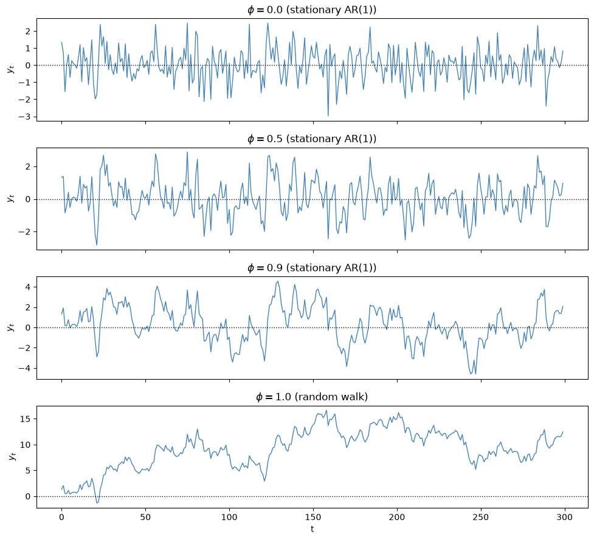

```python
def simulate_ar1(c, phi, sigma_eps, T, rng, y0=0.0):
    #Simulate y_t = c + phi*y_{t-1} + eps_t, starting from y_0 = y0
    eps = rng.normal(loc=0, scale=sigma_eps, size=T)
    y = np.zeros(T)
    y_prev = y0
    for t in range(T):
        y[t] = c + phi * y_prev + eps[t]
        y_prev = y[t]
    return y

T_path = 300
phis = [0.0, 0.5, 0.9, 1.0]

fig, axes = plt.subplots(len(phis), 1, figsize=(10, 9), sharex=True)
for ax, phi in zip(axes, phis):
    rng = np.random.RandomState(10)  #same seed => same shocks in every panel
    y = simulate_ar1(c=0.0, phi=phi, sigma_eps=1.0, T=T_path, rng=rng)
    ax.plot(y, color="steelblue", linewidth=1)
    ax.axhline(0, color="black", linestyle=":", linewidth=1)
    name = "random walk" if phi == 1.0 else "stationary AR(1)"
    ax.set_title(rf"$\phi = {phi}$ ({name})")
    ax.set_ylabel("$y_t$")
axes[-1].set_xlabel("t")
fig.tight_layout()
plt.show()
```

As $\phi$ rises from 0 toward 1, the paths become smoother and swing further from zero, spending longer stretches on one side of it -- exactly the kind of persistence we saw in inflation and the default spread. At $\phi = 1$ the pull back toward zero disappears entirely, and the random walk wanders off.

Next, check the formula $\rho_j = \phi^j$: simulate one long AR(1) series with $\phi = 0.8$ and compare its sample ACF with the theoretical one.

```
Sample variance: 2.739   (theory: 1/(1 - phi^2) = 2.778)
```

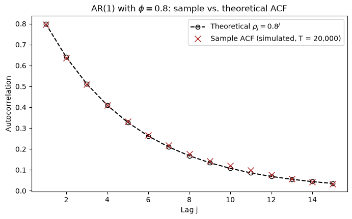

```python
phi_check = 0.8
T_long = 20000
rng = np.random.RandomState(10)
y_long = simulate_ar1(c=0.0, phi=phi_check, sigma_eps=1.0, T=T_long, rng=rng)

lags = np.arange(1, 16)
sample_acf = sm.tsa.acf(y_long, nlags=lags[-1])[1:]
theory_acf = phi_check**lags

print(f"Sample variance: {y_long.var():.3f}   (theory: 1/(1 - phi^2) = {1 / (1 - phi_check**2):.3f})")

fig, ax = plt.subplots(figsize=(8, 4.5))
ax.plot(lags, theory_acf, color="black", linestyle="--", marker="o", markerfacecolor="none",
        label=rf"Theoretical $\rho_j = {phi_check}^j$")
ax.plot(lags, sample_acf, color="firebrick", linestyle="none", marker="x", markersize=9,
        label=f"Sample ACF (simulated, T = {T_long:,})")
ax.set_xlabel("Lag j")
ax.set_ylabel("Autocorrelation")
ax.set_title(rf"AR(1) with $\phi = {phi_check}$: sample vs. theoretical ACF")
ax.legend()
plt.show()
```

With a long simulated sample, the sample ACF lies essentially on top of $\phi^j$, and the sample variance is close to $\sigma^2_\epsilon/(1-\phi^2)$. The derivations check out.

## Estimating AR Models

How do we estimate $c$ and $\phi$? It turns out we can simply run an OLS regression of $y_{t}$ on a constant and its own lag $y_{t-1}$. The fact that AR model parameters can be estimated by OLS makes this class of models very convenient and popular in practice. The `AutoReg` class in `statsmodels` does exactly this.

Let's start with our simulated white-noise series, for which the truth is $\phi = 0$ and mean $10$.

```python
#Fit an AR(1) to the simulated white-noise series
ar_model_simdata = AutoReg(xsim, lags=1).fit()
print(ar_model_simdata.summary())
```

```
                            AutoReg Model Results
==============================================================================
Dep. Variable:                      y   No. Observations:                  200
Model:                     AutoReg(1)   Log Likelihood                -553.062
Method:               Conditional MLE   S.D. of innovations              3.897
Date:                Thu, 01 Oct 2026   AIC                           1112.125
Time:                        10:15:51   BIC                           1122.005
Sample:                             1   HQIC                          1116.123
                                  200
==============================================================================
                 coef    std err          z      P>|z|      [0.025      0.975]
------------------------------------------------------------------------------
const         10.0189      0.779     12.861      0.000       8.492      11.546
y.L1           0.0245      0.071      0.347      0.728      -0.114       0.163
                                    Roots
=============================================================================
                  Real          Imaginary           Modulus         Frequency
-----------------------------------------------------------------------------
AR.1           40.7413           +0.0000j           40.7413            0.0000
-----------------------------------------------------------------------------
```

### Parsing the output

The row labeled `y.L1` is the coefficient on the first lag of $y$, i.e., $\hat\phi$. It is small, and its standard error is relatively large, so we cannot reject the null that the true coefficient is zero -- the right conclusion, since this series has no autocorrelation.

The intercept (`const`) is close to 10 and highly significant. Be careful interpreting it: the intercept is $c$, not the mean, and from the derivation above $c = \mu(1-\phi)$. Here $\hat\phi$ is close to zero, so $\hat c$ is close to the sample mean, which in turn is close to the true mean of 10 we used to simulate the data. (The `Roots` table at the bottom concerns stationarity; see the appendix.)

Now let's apply the AR(1) model to a more interesting series: the default spread.

```python
#Fit an AR(1) to the default spread
ar_model_defspread = AutoReg(df['DEFSPR'], lags=1).fit()
print(ar_model_defspread.summary())

c_hat, phi_hat = ar_model_defspread.params
print(f"\nImplied long-run mean c/(1 - phi): {c_hat / (1 - phi_hat):.3f}   (sample mean: {df['DEFSPR'].mean():.3f})")
```

```
                            AutoReg Model Results
==============================================================================
Dep. Variable:                 DEFSPR   No. Observations:                  317
Model:                     AutoReg(1)   Log Likelihood                  96.832
Method:               Conditional MLE   S.D. of innovations              0.178
Date:                Thu, 01 Oct 2026   AIC                           -187.665
Time:                        10:15:51   BIC                           -176.397
Sample:                    09-30-1947   HQIC                          -183.163
                         - 06-30-2026
==============================================================================
                 coef    std err          z      P>|z|      [0.025      0.975]
------------------------------------------------------------------------------
const          0.0920      0.025      3.677      0.000       0.043       0.141
DEFSPR.L1      0.9017      0.024     36.947      0.000       0.854       0.950
                                    Roots
=============================================================================
                  Real          Imaginary           Modulus         Frequency
-----------------------------------------------------------------------------
AR.1            1.1090           +0.0000j            1.1090            0.0000
-----------------------------------------------------------------------------

Implied long-run mean c/(1 - phi): 0.936   (sample mean: 0.938)
```

### Parsing the output (default spread)

Both the intercept and the slope coefficient are positive and highly significant, and the slope $\hat\phi$ is around 0.9: the default spread is a very persistent series. This is not surprising, given the sample ACF above -- the AR(1) model is capturing that persistence. The implied long-run mean $\hat c/(1-\hat\phi)$ is also very close to the sample mean of the default spread, as the derivation says it should be.

### AR(1) slope = autocorrelation at the first lag

Does the AR(1) slope coefficient look familiar? Compare it with the lag-1 sample autocorrelation of the default spread from the ACF above: they are (nearly) the same.

There is a reason for this. Recall the population slope coefficient in a bivariate linear regression, from `CAPM_BivariateRegression.ipynb`:

$$\beta = \frac{\text{Cov}(x,y)}{\text{Var}(x)}$$

Here the regressor is $x = y_{t-1}$, so

$$\beta = \frac{\text{Cov}(y_{t},y_{t-1})}{\text{Var}(y_{t-1})} = \frac{\text{Cov}(y_{t},y_{t-1})}{\sigma(y_{t})\, \sigma(y_{t-1})} = \rho_{1},$$

where the second equality uses stationarity: $\text{Var}(y_{t-1}) = \sigma(y_{t-1})^2 = \sigma(y_{t})\,\sigma(y_{t-1})$, because $y_t$ and $y_{t-1}$ have the same standard deviation. This matches the derivation above, where we found $\rho_1 = \phi$.

In a finite sample the two *estimates* differ slightly, because the OLS regression and the sample ACF use slightly different means and denominators (e.g., OLS uses only the $T-1$ available pairs $(y_t, y_{t-1})$). The theory also says that under an AR(1), $\rho_j = \phi^j$ at every lag, so we can compare the whole ACF implied by the fitted model with the sample ACF:

```python
lags_def = np.arange(1, 9)
acf_compare = pd.DataFrame({
    'Sample ACF': sm.tsa.acf(df['DEFSPR'], nlags=lags_def[-1])[1:],
    'AR(1)-implied phi_hat^j': phi_hat**lags_def,
}, index=pd.Index(lags_def, name='Lag j'))
acf_compare.round(3)
```

| Lag j | Sample ACF | AR(1)-implied phi_hat^j |
| --- | --- | --- |
| 1 | 0.899 | 0.902 |
| 2 | 0.767 | 0.813 |
| 3 | 0.646 | 0.733 |
| 4 | 0.553 | 0.661 |
| 5 | 0.482 | 0.596 |
| 6 | 0.431 | 0.538 |
| 7 | 0.382 | 0.485 |
| 8 | 0.348 | 0.437 |

The lag-1 values nearly coincide, and the AR(1) captures the broad shape of the decay. But the sample ACF falls off somewhat *faster* than $\hat\phi^j$ in the first few lags. The AR(1) imposes a single decay rate at every lag; the data seem to want a bit more flexibility. That motivates adding more lags.

## Higher-Order AR Models

The reason for the notation AR(1), rather than just AR, is that we don't have to stop at a single lag. An **AR($p$) model** is

$$y_{t} = c + \phi_{1}\, y_{t-1} + \phi_{2}\, y_{t-2} + \cdots + \phi_{p}\, y_{t-p} + \epsilon_{t},$$

where again $\epsilon_{t}$ is white noise. This is a multivariate regression model, like the multifactor regressions in `MultifactorModels_MultiVarRegression.ipynb` -- the regressors just happen to be lags of $y$ itself -- and its parameters can likewise be estimated by OLS.

What about the conditions for an AR($p$) model to be stationary? These are more complicated than $|\phi| < 1$: they involve the roots of a certain polynomial, which is what the `Roots` table at the bottom of the `AutoReg` output reports. The short version is that we want every root's `Modulus` to be greater than one. The appendix explains this, but it is not needed for the rest of the notebook.

### How many lags? Information criteria

Adding lags can only improve the in-sample fit, so fit alone can't tell us when to stop -- we would always add more lags and end up *overfitting*. **Information criteria** such as AIC, BIC, and HQIC (all reported in the `AutoReg` output) are measures of "penalized fit": they reward a better fit but charge a penalty for each extra parameter. **Lower is better.** The three differ only in how heavily they penalize extra parameters -- AIC the least, BIC the most -- so they can disagree, with AIC the most willing to pick a larger model. (See the appendix for the formulas.)

Let's compare AR(1) and AR(2) fits for real GDP growth. The `hold_back=2` option below makes sure both models are estimated on the same sample, so their criteria are comparable (see the appendix).

```python
def compare_ar1_ar2(y):
    #Fit AR(1) and AR(2) on a common sample and summarize coefficients, p-values, and information criteria
    fits = {f'AR({p})': AutoReg(y, lags=p, hold_back=2).fit() for p in [1, 2]}
    rows = {}
    for name, res in fits.items():
        row = {}
        for param in res.params.index:
            row[f'{param} coef'] = res.params[param]
            row[f'{param} p-value'] = res.pvalues[param]
        row.update({'AIC': res.aic, 'BIC': res.bic, 'HQIC': res.hqic, 'nobs': res.nobs})
        rows[name] = row
    #List rows in the AR(2) order (coefficients first, then criteria); the AR(1) has no second-lag entries
    return fits, pd.DataFrame(rows).reindex(rows['AR(2)'].keys())

gdp_fits, gdp_table = compare_ar1_ar2(df['GDP'])
gdp_table.round(3)
```

|  | AR(1) | AR(2) |
| --- | --- | --- |
| const coef | 2.788 | 2.513 |
| const p-value | 0.000 | 0.000 |
| GDP.L1 coef | 0.132 | 0.119 |
| GDP.L1 p-value | 0.018 | 0.034 |
| GDP.L2 coef | NaN | 0.100 |
| GDP.L2 p-value | NaN | 0.074 |
| AIC | 1841.288 | 1840.121 |
| BIC | 1852.545 | 1855.131 |
| HQIC | 1845.786 | 1846.118 |
| nobs | 315.000 | 315.000 |

### Interpreting the results

In both models, the intercept is positive and significant, and the coefficient on the first lag of GDP growth is positive and significant at the 5% level: this quarter's growth helps predict next quarter's, consistent with the positive (if small) autocorrelations we saw earlier. Both lag coefficients are small, though -- well below the 0.9 or so we found for the default spread.

In the AR(2) model, the coefficient on the second lag is also positive but only marginally significant (its p-value is above 0.05). The information criteria reflect this ambiguity: they *disagree*. AIC, with the lightest penalty, is lower for the AR(2); BIC, with the heaviest penalty, prefers the more parsimonious AR(1); HQIC is essentially a toss-up. This is a common outcome in practice when the extra lag has only a modest effect, and it's a reminder that model selection is a judgment call, not a mechanical procedure.

### How much does COVID matter?

Recall the extreme 2020 observations in the GDP plot: an annualized drop of nearly 30% followed by a rebound of more than 30%. A huge drop followed immediately by a huge rise looks, to OLS, like strong *negative* autocorrelation, and because OLS squares the errors, two observations this extreme carry a lot of weight. Let's re-estimate using only the pre-COVID data, through 2019Q4.

```python
gdp_fits_pre, gdp_table_pre = compare_ar1_ar2(df.loc[:'2019Q4', 'GDP'])
gdp_table_pre.round(3)
```

|  | AR(1) | AR(2) |
| --- | --- | --- |
| const coef | 2.105 | 1.870 |
| const p-value | 0.000 | 0.000 |
| GDP.L1 coef | 0.356 | 0.314 |
| GDP.L1 p-value | 0.000 | 0.000 |
| GDP.L2 coef | NaN | 0.114 |
| GDP.L2 p-value | NaN | 0.050 |
| AIC | 1561.787 | 1559.971 |
| BIC | 1572.786 | 1574.636 |
| HQIC | 1566.194 | 1565.847 |
| nobs | 289.000 | 289.000 |

Dropping just the post-2019 data makes GDP growth look noticeably *more* persistent: the first-lag coefficient nearly triples in the AR(1), and it is very precisely estimated. The second lag in the AR(2) is still modest, but the balance of evidence (AIC and HQIC) now tilts a bit more toward the AR(2), while BIC still prefers the AR(1).

The broader lesson: persistence estimates, and the model choices built on them, can be sensitive to a handful of extreme observations. It is always worth plotting your data and checking whether a few unusual periods are driving your conclusions. For the forecasting example below we stick with the full-sample AR(2), and return to the COVID period in the exercise at the end.

## Forecasting: A Basic Introduction

One major application of time series models is **forecasting**: predicting future outcomes of a time series given the information available today.

How should we make a forecast? If we measure the cost of a forecast error by its *squared* magnitude (just as OLS does), then the optimal forecast of a variable is its **conditional expectation** (equivalently, "conditional mean") given everything we currently know.

### Information sets and conditional expectations

The notation $\mathcal{F}_{t}$ denotes the *information set* available at time $t$. It includes past and current values of the series, and possibly other variables, but *not* future values. For example, $\mathcal{F}_{t}$ for September 28, 2026 contains all stock returns up to and including those realized on September 28, 2026, along with everything else known at that time, such as interest rates, exchange rates, or recent weather -- but not tomorrow's stock prices.

We will often take conditional expectations given the information set, with the shorthand

$$E[y_{t+h} \mid \mathcal{F}_{t}] \equiv E_{t}[y_{t+h}]$$

Sometimes we explicitly name the random variables that make up $\mathcal{F}_{t}$, e.g. $E[y_{t+h} \mid y_{t}, y_{t-1},\ldots]$.

### Computing forecasts in AR models

Fortunately, conditional expectations are easy to compute in an AR model. Take the AR(1) as an example, with information set $\mathcal{F}_{t} = \{y_{t}, y_{t-1}, \ldots\}$ (all past and current values of $y$ are observed). The model implies

$$y_{t+1} = c + \phi\, y_{t} + \epsilon_{t+1}$$

Take the conditional expectation of both sides:

$$E(y_{t+1} \mid \mathcal{F}_{t}) = E(c + \phi\, y_{t} + \epsilon_{t+1} \mid \mathcal{F}_{t}) = c + \phi\, y_{t} + E(\epsilon_{t+1} \mid \mathcal{F}_{t}) = c + \phi\, y_{t}$$

*Intuition*: $y_{t}$ is known at time $t$, so we just plug its value into the right-hand side. The future shock $\epsilon_{t+1}$ is not known, and we assume it is *unpredictable* from past information, so its conditional expectation is zero. (This is a slightly stronger assumption than white noise; see the appendix.)

Now forecast *two* periods ahead. Substitute the model for $y_{t+1}$ into the model for $y_{t+2}$:

$$y_{t+2} = c + \phi\, y_{t+1} + \epsilon_{t+2} = c + \phi\,(c + \phi\, y_{t} + \epsilon_{t+1}) + \epsilon_{t+2} = c + \phi c + \phi^{2} y_{t} + \phi\,\epsilon_{t+1} + \epsilon_{t+2}$$

Taking conditional expectations, both future shocks drop out:

$$E(y_{t+2} \mid \mathcal{F}_{t}) = c + \phi c + \phi^{2} y_{t}$$

This is the forecast for $t+2$ given information (specifically, $y_{t}$) at time $t$. Continuing the same way, the $j$-period-ahead forecast is

$$E(y_{t+j} \mid \mathcal{F}_{t}) = c\,(1 + \phi + \cdots + \phi^{j-1}) + \phi^{j} y_{t}$$

The same result is easier to read in deviation-from-mean form (a little algebra, shown in the appendix):

$$E(y_{t+j} \mid \mathcal{F}_{t}) - \mu = \phi^{j}\,(y_{t} - \mu)$$

In words: *today's gap from the long-run mean shrinks by a factor of $\phi$ for each period we look ahead.* For a stationary model ($|\phi| < 1$), $\phi^j \to 0$ as $j \to \infty$, so the forecast converges to $\mu = \frac{c}{1-\phi}$, the *unconditional* mean of $y$. As we look farther into the future, the current state $y_{t}$ becomes less and less relevant, and our best forecast approaches the unconditional average. The more persistent the series, the slower this happens.

The discussion above assumes we know $c$ and $\phi$. In practice, we plug in the OLS estimates, so, for example, the one-step-ahead forecast is

$$\hat{y}_{t+1} = \hat{c} + \hat{\phi}\, y_{t}$$

The same logic extends to AR($p$) models, and `statsmodels` will produce the forecasts for us. The example below forecasts GDP growth over the next 12 quarters using the full-sample AR(2) model estimated above. For an AR(2), the unconditional mean is $\mu = c/(1 - \phi_1 - \phi_2)$, by the same take-expectations-of-both-sides argument as for the AR(1).

```python
ar2_model_gdp = gdp_fits['AR(2)']
horizon = 12
gdp_forecasts = ar2_model_gdp.forecast(steps=horizon)

c2, phi1, phi2 = ar2_model_gdp.params
mu_ar2 = c2 / (1 - phi1 - phi2)

print("Last two observed quarters of GDP growth:")
print(df['GDP'].tail(2).round(2).to_string())
print(f"\nAR(2)-implied unconditional mean: {mu_ar2:.2f}   (sample mean: {df['GDP'].mean():.2f})")
print("\nForecasts:")
print(gdp_forecasts.round(2).to_string())
```

```
Last two observed quarters of GDP growth:
DATE
2026Q1    2.09
2026Q2    1.48
Freq: Q-DEC

AR(2)-implied unconditional mean: 3.21   (sample mean: 3.19)

Forecasts:
2026Q3    2.90
2026Q4    3.00
2027Q1    3.16
2027Q2    3.19
2027Q3    3.21
2027Q4    3.21
2028Q1    3.21
2028Q2    3.21
2028Q3    3.21
2028Q4    3.21
2029Q1    3.21
2029Q2    3.21
Freq: Q-DEC
```

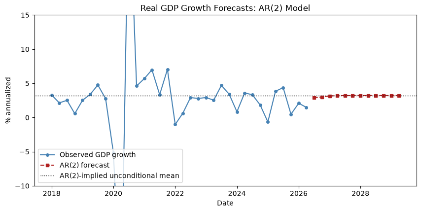

```python
#Plot recent data together with the forecasts
recent = df.loc['2018Q1':, 'GDP']

fig, ax = plt.subplots(figsize=(10, 4.5))
ax.plot(recent.index.to_timestamp(), recent, color="steelblue", marker="o", markersize=4,
        label="Observed GDP growth")
ax.plot(gdp_forecasts.index.to_timestamp(), gdp_forecasts, color="firebrick", linestyle="--",
        marker="s", markersize=5, label="AR(2) forecast")
ax.axhline(mu_ar2, color="black", linestyle=":", linewidth=1, label="AR(2)-implied unconditional mean")
ax.set_ylim(-10, 15)
ax.set_xlabel("Date")
ax.set_ylabel("% annualized")
ax.set_title("Real GDP Growth Forecasts: AR(2) Model")
ax.legend(loc="lower left")
plt.show()
```

### Discussion

Key points from the output and figure (the y-axis is cut at $-10\%$ and $+15\%$ so the recent data are readable; the 2020 COVID quarters run off the chart). (If you switch to the optional live FRED pull in the first code cell, the specific quarters and values below will shift as new data are released and old data are revised.)

1. The two most recent observations (2026Q1 and 2026Q2) are both below the unconditional mean. The AR(2) forecast uses both, so the forecast for next quarter also starts below the mean -- but closer to it, since the small lag coefficients pull only a fraction of the current shortfall forward.
2. After that, the forecasts converge quickly to the unconditional mean and then barely move. That is because both estimated lag coefficients are small: GDP growth, as measured here, is not very persistent, so the current state of the economy carries little information about growth more than a few quarters ahead.
3. For a much more persistent series, like the default spread ($\hat\phi \approx 0.9$), a current value far from the mean would lead to forecasts that return to the mean only gradually, over many quarters -- try it!

### Exercise

Think about how this forecasting model would have performed around COVID. For simplicity, fix the model parameters at the full-sample AR(2) values estimated above. Now imagine being at the end of 2020Q2, right after the COVID collapse. What would the model have forecast for the next several quarters? How well would those forecasts have performed relative to a simple benchmark that always forecasts the unconditional average GDP growth? What does this suggest about using a linear AR model around rare, extreme events?

## Takeaways

- Many macro-financial series are clearly not independent over time. Inflation and especially the default spread are highly persistent, with sample autocorrelations that start high (around 0.9 for the default spread) and decay slowly; real GDP growth has much weaker, but still statistically detectable, autocorrelation.
- Stationarity -- a constant mean and autocovariances that depend only on the lag -- is what lets us learn about a series' dynamics from a single history. Trending series like price levels or the level of GDP are typically made stationary by taking growth rates or differences, which is exactly why we analyze returns rather than prices.
- Reading an ACF plot one lag at a time invites false positives: in simulation, pure white noise showed at least one "significant" lag in more than half of samples. The Ljung-Box test addresses this with a single joint test. It overwhelmingly rejects white noise for inflation and the default spread; for GDP growth, whether it rejects depends on the number of lags $K$ included -- a reminder that test choices should be made before looking at results.
- The AR(1) model $y_t = c + \phi y_{t-1} + \epsilon_t$ is stationary when $|\phi| < 1$, has mean $c/(1-\phi)$, variance $\sigma^2_\epsilon/(1-\phi^2)$, and a geometrically decaying ACF $\rho_j = \phi^j$ -- all confirmed by simulation. The OLS slope is (essentially) the lag-1 autocorrelation.
- AR($p$) models are just regressions on lagged values of the series itself. Information criteria trade fit against complexity and can disagree, and for GDP growth the estimates turned out to be quite sensitive to the two COVID quarters.
- The optimal (squared-error) forecast is the conditional expectation. In an AR(1), the forecast gap from the long-run mean shrinks by a factor $\phi$ per period, so forecasts revert to the unconditional mean -- quickly for weakly persistent series like GDP growth, slowly for highly persistent ones like the default spread.

**Where this goes next.** Autocorrelation is the key ingredient behind the Newey-West standard errors in `Equity_Premium_Inference.ipynb`, and forecasting with lagged predictors is the foundation for the return-predictability and machine-learning forecasting topics later in the course, where the same questions -- is there real predictability, and how do we avoid fooling ourselves with overfitting and multiple testing? -- come up again in a richer setting.

## Additional Technical Material

This appendix collects technical details that were stated without proof in the main text above, in the order they come up.

### Why $\rho_j = \rho_{-j}$ for a stationary series

By definition, $\gamma_{-j} = \text{Cov}(y_{t}, y_{t+j})$. Stationarity says the covariance between two dates depends only on how far apart they are, not on the dates themselves, so we can shift both dates back by $j$ periods without changing it: $\text{Cov}(y_{t}, y_{t+j}) = \text{Cov}(y_{t-j}, y_{t}) = \gamma_{j}$. Dividing both sides by $\gamma_0$ gives $\rho_{-j} = \rho_j$.

### Uncorrelated versus independent: volatility clustering

It may be hard to see how independence is a stronger restriction than zero correlation. How can a series be uncorrelated but *not* independent? A good example is *volatility clustering*: the amplitude (volatility) of the outcomes can fluctuate smoothly over time, so that if recent outcomes were large in magnitude, we expect the next outcome to be relatively large in magnitude too -- but equally likely to be positive or negative. The *signs* are unpredictable, so all of the autocorrelations can be zero, but the *magnitudes* are predictable, so the outcomes are not independent. Daily stock returns are the classic example: nearly uncorrelated from day to day, but with strongly clustered volatility.

### Why the ACF confidence bands widen: Bartlett's formula

The simple result $\sqrt{T}\hat\rho_j \xrightarrow{d} N(0,1)$ holds when the series is independent white noise, i.e., when *all* autocorrelations are zero. When we look at lag $j$ of a series that may be autocorrelated at shorter lags, a more relevant null is: "$\rho_j = 0$, and all autocorrelations beyond lag $j$ are zero too, but $\rho_1, \ldots, \rho_{j-1}$ may be nonzero." Under that null, **Bartlett's formula** gives the approximate variance of the sample autocorrelation:

$$\text{Var}(\hat\rho_j) \approx \frac{1}{T}\left(1 + 2\sum_{i=1}^{j-1}\rho_i^2\right)$$

`statsmodels` plugs in the sample autocorrelations $\hat\rho_i$ for the unknown $\rho_i$ and draws the band at $\pm 1.96$ times the square root of this variance (this is the default `bartlett_confint=True` option of `plot_acf`). At lag 1 the sum is empty, and the band is the simple $\pm 1.96/\sqrt{T}$. At each further lag, the band widens by an amount that depends on how large the earlier sample autocorrelations are: barely at all for white noise, but a lot for the default spread, whose early autocorrelations are close to 1.

*Intuition*: if $y_t$ is strongly correlated with its recent past, then the products $\tilde y_t \tilde y_{t-j}$ that go into $\hat\gamma_j$ are themselves correlated over time, so averaging them reduces noise less effectively than averaging independent terms -- the same "dependence inflates variance" effect we saw for the sample mean in `Equity_Premium_Inference.ipynb`.

### The Ljung-Box statistic

The Ljung-Box statistic, which `statsmodels` reports, is

$$LB(K) = T(T+2)\sum_{k=1}^{K} \frac{\hat{\rho}^2_{k}}{T-k}$$

Compared with Box-Pierce, $Q(K) = T\sum_{k=1}^{K}\hat\rho_k^2$, each squared autocorrelation gets weight $T(T+2)/(T-k)$ instead of $T$. The reason: in a finite sample, the variance of $\hat\rho_k$ under the null is closer to $(T-k)/\big(T(T+2)\big)$ than to $1/T$. (Part of the reason is that only $T - k$ pairs of observations go into $\hat\rho_k$.) Dividing each $\hat\rho_k^2$ by this more accurate variance makes each term closer to a squared standard Normal, so $LB(K)$ is closer to its $\chi^2(K)$ distribution than $Q(K)$ is. When $T$ is large relative to $K$, the weights are all close to $T$ and the two statistics nearly coincide.

### Variance and autocorrelations of a stationary AR(1)

Assume $|\phi| < 1$, so that $\text{Var}(y_t) = \text{Var}(y_{t-1}) = \gamma_0$. The shock $\epsilon_t$ is uncorrelated with $y_{t-1}$ (which depends only on shocks dated $t-1$ and earlier), so covariance terms involving $\epsilon_t$ and past $y$'s vanish.

**Variance.** Take variances of both sides of $y_t = c + \phi\, y_{t-1} + \epsilon_t$:

$$\gamma_0 = \text{Var}(c + \phi\, y_{t-1} + \epsilon_{t}) = \phi^2\, \text{Var}(y_{t-1}) + \text{Var}(\epsilon_t) + 2\phi\,\underbrace{\text{Cov}(y_{t-1}, \epsilon_t)}_{=0} = \phi^2 \gamma_0 + \sigma^2_\epsilon$$

Solving for $\gamma_0$ gives $\gamma_0 = \sigma^2_\epsilon/(1 - \phi^2)$.

**Autocorrelations.** The lag-1 autocovariance is

$$\gamma_1 = \text{Cov}(y_t, y_{t-1}) = \text{Cov}(c + \phi\, y_{t-1} + \epsilon_{t},\; y_{t-1}) = \phi\, \text{Var}(y_{t-1}) + \underbrace{\text{Cov}(\epsilon_t, y_{t-1})}_{=0} = \phi\,\gamma_0$$

so $\rho_1 = \gamma_1 / \gamma_0 = \phi$. The same step at lag $j$ -- write $y_t = c + \phi\, y_{t-1} + \epsilon_t$ and take the covariance with $y_{t-j}$ -- gives $\gamma_j = \phi\,\gamma_{j-1}$. So each extra lag multiplies the autocovariance (and the autocorrelation) by $\phi$, and $\rho_j = \phi^j$.

### Stationarity of AR($p$) models and the "Roots" table

**Note: this subsection uses complex numbers (numbers of the form $a + bi$ with $i = \sqrt{-1}$), which are beyond this course's prerequisites. It is safe to skip.**

For the AR($p$) model $y_{t} = c + \phi_{1} y_{t-1} + \cdots + \phi_{p} y_{t-p} + \epsilon_{t}$, define the *characteristic polynomial*

$$\Phi(z) = 1 - \phi_1 z - \phi_2 z^2 - \cdots - \phi_p z^p$$

The AR($p$) model is stationary if and only if every root of $\Phi(z) = 0$ lies *outside the unit circle*, i.e., has modulus (absolute value) greater than 1. The roots can be complex numbers, which is why the `Roots` table in the `AutoReg` output reports `Real` and `Imaginary` parts, the `Modulus` $\sqrt{\text{Real}^2 + \text{Imaginary}^2}$, and a `Frequency` (the root's angle, which governs how fast any cycles in the series oscillate).

*Check with the AR(1)*: here $\Phi(z) = 1 - \phi z$, whose single root is $z = 1/\phi$. Its modulus exceeds 1 exactly when $|\phi| < 1$ -- the condition we derived directly. For the default spread, $\hat\phi \approx 0.90$, so the root is about $1/0.90 \approx 1.11$, which is the `Modulus` reported in the output above: stationary, but not by a wide margin.

For the AR(2), the root condition turns out to be equivalent to three simple inequalities on the coefficients:

$$\phi_1 + \phi_2 < 1, \qquad \phi_2 - \phi_1 < 1, \qquad |\phi_2| < 1$$

When a pair of roots is complex, the ACF of the process oscillates (like a damped sine wave) as it decays, rather than decaying smoothly -- this is how AR models can generate business-cycle-like behavior.

### Information criteria

Up to scaling conventions that differ across software, the three criteria reported by `AutoReg` are

$$\text{AIC} = -2\ln L + 2k, \qquad \text{BIC} = -2\ln L + k\ln T, \qquad \text{HQIC} = -2\ln L + 2k\ln(\ln T),$$

where $\ln L$ is the maximized log-likelihood (a measure of fit; higher is better) and $k$ is the number of estimated parameters. The first term rewards fit and the second penalizes parameters. For any realistic sample size ($T \geq 16$), the per-parameter penalty is smallest for AIC ($2$), in between for HQIC ($2\ln\ln T$), and largest for BIC ($\ln T$).

*Comparing on a common sample.* An AR($p$) regression loses the first $p$ observations, which have no lags available. By default, then, an AR(1) and an AR(2) are fit on *different* samples (the AR(2) has one fewer observation), and their log-likelihoods are not directly comparable. The `hold_back=2` option makes both models drop the same first two observations, so both are estimated on the same sample.

### Forecasting details

*Unpredictable shocks.* The forecasting derivations use $E(\epsilon_{t+1} \mid \mathcal{F}_t) = 0$: the shock cannot be predicted from anything known at time $t$. This is a slightly stronger assumption than $\epsilon_t$ merely being white noise (uncorrelated). It holds, for instance, if the shocks are independent white noise. Recall the volatility-clustering example above: zero correlation rules out *linear* predictability, but not every kind of predictability.

*Deviation-from-mean form.* Start from the $j$-step forecast

$$E(y_{t+j} \mid \mathcal{F}_{t}) = c\,(1 + \phi + \cdots + \phi^{j-1}) + \phi^{j} y_{t}.$$

The geometric sum is $1 + \phi + \cdots + \phi^{j-1} = (1-\phi^j)/(1-\phi)$, and $c = \mu(1-\phi)$, so the first term equals $\mu(1-\phi)\cdot(1-\phi^j)/(1-\phi) = \mu(1-\phi^j)$. Then

$$E(y_{t+j} \mid \mathcal{F}_{t}) = \mu - \phi^j \mu + \phi^{j} y_{t} \quad\Longrightarrow\quad E(y_{t+j} \mid \mathcal{F}_{t}) - \mu = \phi^{j}\,(y_{t} - \mu).$$